# Fertilizer Regime Experiment - Experiment VI

Olamide Adu

2023-03-25

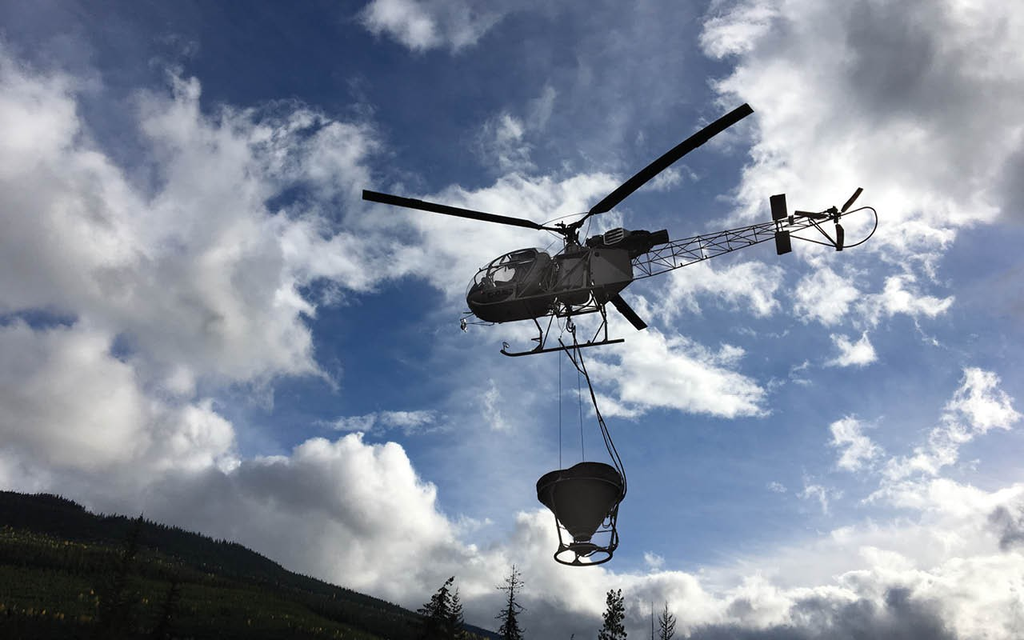

*source: Pique Newsmagazine*  
Fertilization of plantations in Sweden is region specific. In the Northern part of Sweden the use of fertilizer is common, while in the Southern region its use is prohibited. The Southern part is having rich soil and have no need to fertilize the soil. Swedish forest fertilization mainly involves the application of Nitrogen which is normally the limiting nutrient for high stand growth. Different fertilization experiments have been set to either see the effect of different fertilizers on stand development or see the effect of fertilization application frequency on the stand development.

This experiment is set to see the effect of fertilization frequency on the growth of a stand. The experiment is a young Norway Spruce stands which was established with 5 blocks having randomly distributed treatments in 0.1 ha plots. The treatments are with 3 different intensities in fertilization

- F1: Fertilized every year
- F2: Fertilized every second year
- F3: Fertilized every third year
- C: Control without fertilzation.

The amount of nutrients over time was calculated to be more or less the same in F1 F2 and F3.

The volume (m3/ha) and CAI (m3 ha-1yr-1) were calculated for every treatment plot in all blocks.

##Questions

```
-   is there a significant effect of treatment compared to control?

-   Do you find a significant difference in between the different treatments, meaning fertilization intensity

-   Do you find any different effect of treatment early on in the experiment compared to later revisions
```

```r
library(doBy)
library(dplyr)
```

```r
library(lattice)
library(ggplot2)
library(car)
library(data.table)
library(TukeyC)
```

**Importing the data**

```r
expfert <- read.table('https://raw.githubusercontent.com/xrander/SLU-Plantation-Experimentation/master/Data/Lab6/expfert.txt',
           header = T,
           sep = '\t',
           na.strings = 'NA',
           dec = '.',
           strip.white = T)
```

**A Little Data Exploration**

```r
str(expfert)
```

```
## 'data.frame':    80 obs. of  7 variables:
##  $ block    : int  1523 1523 1523 1523 1523 1523 1523 1523 1523 1523 ...
##  $ revision : int  1 1 1 1 4 4 4 4 5 5 ...
##  $ treatment: chr  "C" "F1" "F2" "F3" ...
##  $ volume   : num  11.27 8.07 8.13 7.53 28.83 ...
##  $ CAI      : num  0 0 0 0 6.43 ...
##  $ domheight: num  5.77 5.37 5 5.2 7.83 ...
##  $ age      : int  20 20 20 20 25 25 25 25 30 30 ...
```

```r
summary(expfert)
```

```
##      block         revision     treatment             volume
##  Min.   :1523   Min.   :1.00   Length:80          Min.   :  1.767
##  1st Qu.:1524   1st Qu.:3.25   Class :character   1st Qu.: 14.667
##  Median :1525   Median :4.50   Mode  :character   Median : 54.050
##  Mean   :1525   Mean   :4.00                      Mean   : 86.636
##  3rd Qu.:1526   3rd Qu.:5.25                      3rd Qu.:134.154
##  Max.   :1527   Max.   :6.00                      Max.   :280.400
##       CAI          domheight           age
##  Min.   : 0.00   Min.   : 0.000   Min.   :13.0
##  1st Qu.: 1.75   1st Qu.: 5.667   1st Qu.:20.0
##  Median :11.68   Median : 9.200   Median :25.0
##  Mean   :10.76   Mean   : 8.926   Mean   :26.1
##  3rd Qu.:17.71   3rd Qu.:12.858   3rd Qu.:30.0
##  Max.   :28.57   Max.   :16.867   Max.   :35.0
```

**To check the number of replications we have in this experiment**

```r
ftable(expfert$block, expfert$treatment, expfert$revision)
```

```
##          1 4 5 6
##
## 1523 C   1 1 1 1
##      F1  1 1 1 1
##      F2  1 1 1 1
##      F3  1 1 1 1
## 1524 C   1 1 1 1
##      F1  1 1 1 1
##      F2  1 1 1 1
##      F3  1 1 1 1
## 1525 C   1 1 1 1
##      F1  1 1 1 1
##      F2  1 1 1 1
##      F3  1 1 1 1
## 1526 C   1 1 1 1
##      F1  1 1 1 1
##      F2  1 1 1 1
##      F3  1 1 1 1
## 1527 C   1 1 1 1
##      F1  1 1 1 1
##      F2  1 1 1 1
##      F3  1 1 1 1
```

We have 4 revisions and 5 replicates

We can check a quick visual on how the experiment have been measured repeatedly overtime (revisions)

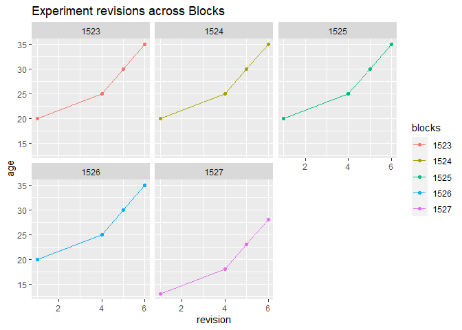

```r
ggplot (expfert, aes(revision, age, color = factor(block)))+
  geom_point()+
  geom_line()+
  facet_wrap(~block, ncol = 3)+
  labs(title = 'Experiment revisions across Blocks',
       x = 'revision',
       y = 'age',
       color = 'blocks')
```

**Visualizing CAI changes over the revisions**

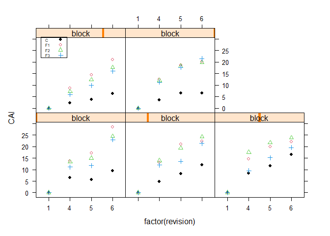

```r
xyplot(CAI~factor(revision)|block,
       groups=treatment,data=expfert,
       par.settings=simpleTheme(col=c(1,2,3,4),pch=c(16,1,2,3)), #adding settings for symbology
       auto.key=list(corner = c(0.02, 0.94),border="black",cex=0.5,points=T))
```

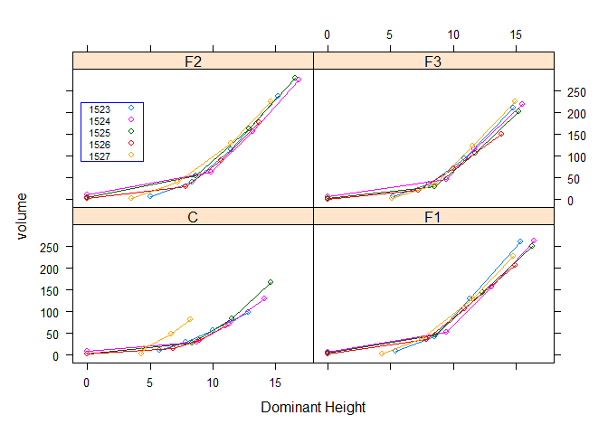

```r
xyplot(volume~domheight | treatment,
       group = block,
       data = expfert,
       type = 'b',
       xlab = 'Dominant Height',
       auto.key = list(corner = c(0.02,0.8), border = 'blue', cex = 0.7))
```

## Volume and CAI at the different blocks for the different treatments

### Volume

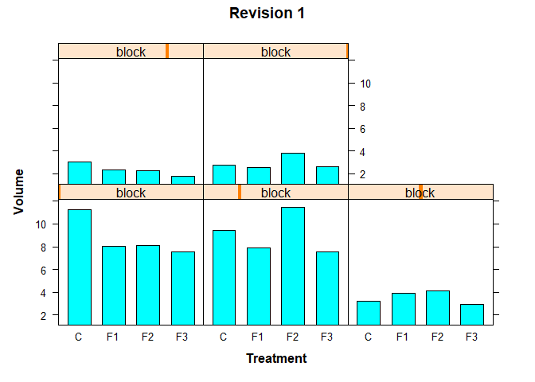

```r
barchart(volume~treatment|block, data = expfert,
         subset = revision == 1,
         main = 'Revision 1',
         ylab = substitute(paste(bold('Volume'))),
         xlab = substitute(paste(bold('Treatment'))))
```

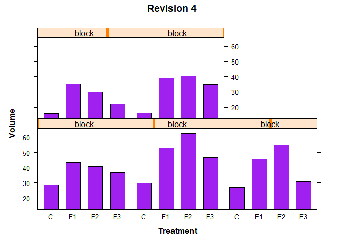

```r
barchart(volume~treatment|block, data = expfert,
         subset = revision == 4,
         main = 'Revision 4',
         col = 'purple',
         ylab = substitute(paste(bold('Volume'))),
         xlab = substitute(paste(bold('Treatment'))))
```

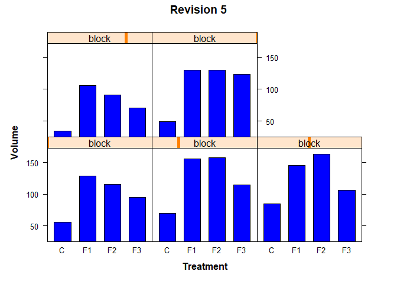

```r
barchart(volume~treatment|block, data = expfert,
         subset = revision == 5,
         main = 'Revision 5',
         col = 'blue',
         ylab = substitute(paste(bold('Volume'))),
         xlab = substitute(paste(bold('Treatment'))))
```

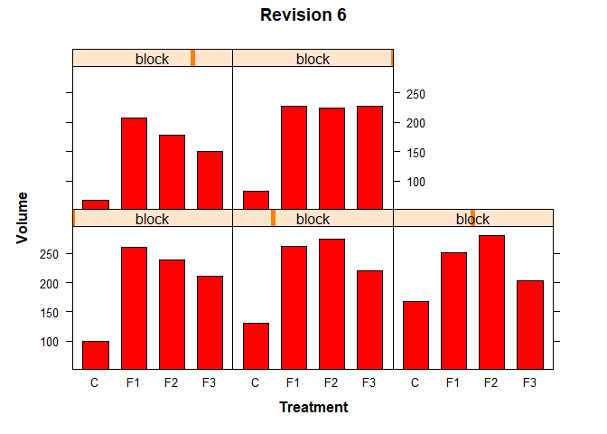

```r
barchart(volume~treatment|block, data = expfert,
         subset = revision == 6,
         main = 'Revision 6',
         col = 'red',
         ylab = substitute(paste(bold('Volume'))),
         xlab = substitute(paste(bold('Treatment'))))
```

### CAI

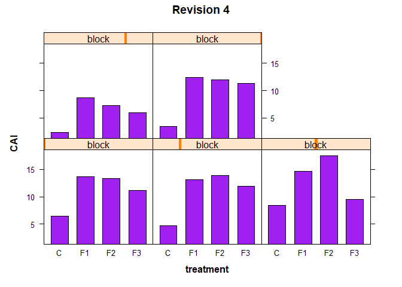

```r
barchart(CAI~treatment | block, data = expfert,
         subset = revision == 4,
         col = 'purple',
         main = 'Revision 4',
         xlab = substitute(paste(bold('treatment'))),
         ylab = substitute(paste(bold('CAI'))))
```

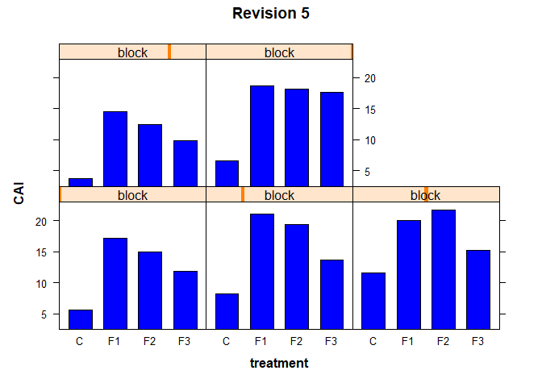

```r
barchart(CAI~treatment|block, data = expfert,
         subset = revision == 5,
         col = 'blue',
         main = 'Revision 5',
         xlab = substitute(paste(bold('treatment'))),
         ylab = substitute(paste(bold('CAI'))))
```

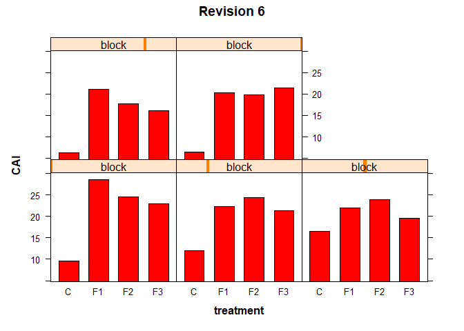

```r
barchart(CAI~treatment|block, data = expfert,
         subset = revision == 6,
         col = 'red',
         main = 'Revision 6',
         xlab = substitute(paste(bold('treatment'))),
         ylab = substitute(paste(bold('CAI'))))
```

## Dominant Height across treatments

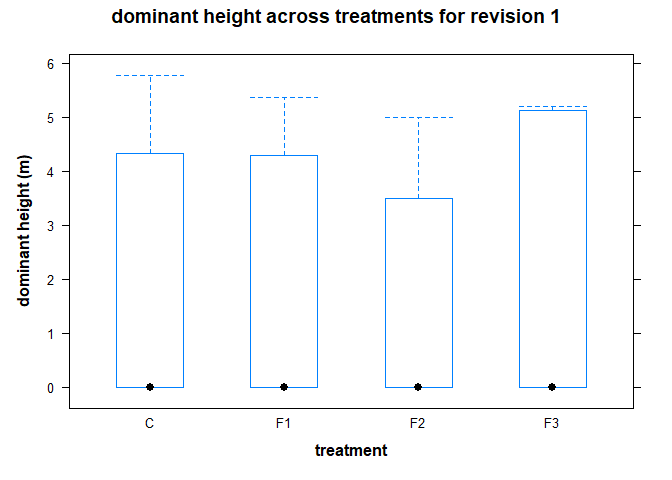

```r
bwplot(domheight~treatment, subset=revision==1, data = expfert,
       xlab = substitute(paste(bold('treatment'))),
       ylab = substitute(paste(bold('dominant height (m)'))),
       main = 'dominant height across treatments for revision 1')
```

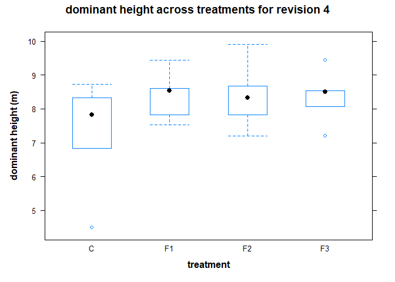

```r
bwplot(domheight~treatment, subset=revision==4, data = expfert,
       xlab = substitute(paste(bold('treatment'))),
       ylab = substitute(paste(bold('dominant height (m)'))),
       main = 'dominant height across treatments for revision 4')
```

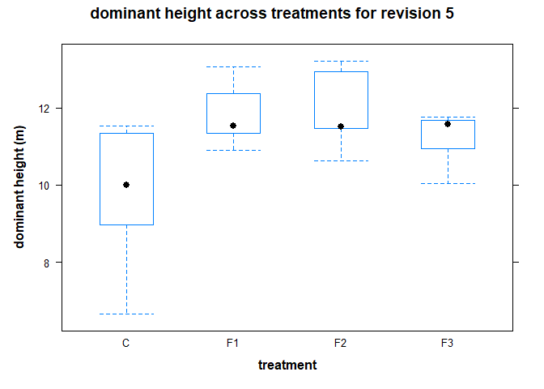

```r
bwplot(domheight~treatment, subset=revision==5, data = expfert,
       xlab = substitute(paste(bold('treatment'))),
       ylab = substitute(paste(bold('dominant height (m)'))),
       main = 'dominant height across treatments for revision 5')
```

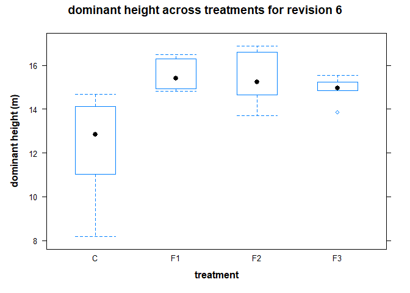

```r
bwplot(domheight~treatment, subset=revision==6, data = expfert,
       xlab = substitute(paste(bold('treatment'))),
       ylab = substitute(paste(bold('dominant height (m)'))),
       main = 'dominant height across treatments for revision 6')
```

## Analysis of Variance to see the effect of the treatments on the volume produced

### Revision of 4

```r
M.vol <- lm(volume~block+treatment,
            data = expfert[expfert$revision==4,])
M.vol
```

```
##
## Call:
## lm(formula = volume ~ block + treatment, data = expfert[expfert$revision ==
##     4, ])
##
## Coefficients:
## (Intercept)        block  treatmentF1  treatmentF2  treatmentF3
##    4847.563       -3.163       19.740       22.287       10.807
```

```r
anova(M.vol)
```

```
## Analysis of Variance Table
##
## Response: volume
##           Df  Sum Sq Mean Sq F value   Pr(>F)
## block      1  400.27  400.27  6.2491 0.024515 *
## treatment  3 1526.53  508.84  7.9442 0.002098 **
## Residuals 15  960.78   64.05
## ---
## Signif. codes:  0 '***' 0.001 '**' 0.01 '*' 0.05 '.' 0.1 ' ' 1
```

#### Posthoc test using Tukeyhsd

```r
T.vol <- TukeyC(x = M.vol, which = 'treatment')
summary(T.vol)
```

```
## Goups of means at sig.level = 0.05
##    Means G1 G2
## F2 45.77  a
## F1 43.22  a
## F3 34.29  a  b
## C  23.48     b
##
## Matrix of the difference of means above diagonal and
## respective p-values of the Tukey test below diagonal values
##       F2    F1     F3      C
## F2 0.000 2.547 11.480 22.287
## F1 0.957 0.000  8.933 19.740
## F3 0.150 0.327  0.000 10.807
## C  0.003 0.007  0.187  0.000
```

**Checking for patterns in the residuals with a residual plot**

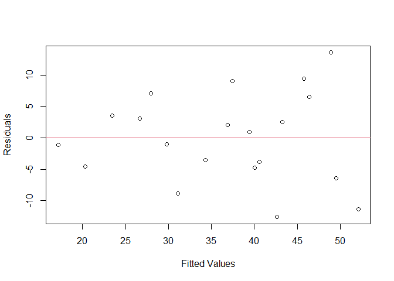

```r
plot(M.vol$fitted.values, M.vol$residuals,
     xlab = 'Fitted Values',
     ylab = 'Residuals')
abline (c(0,0), col = 2)
```

**Getting more information using base r plot function**

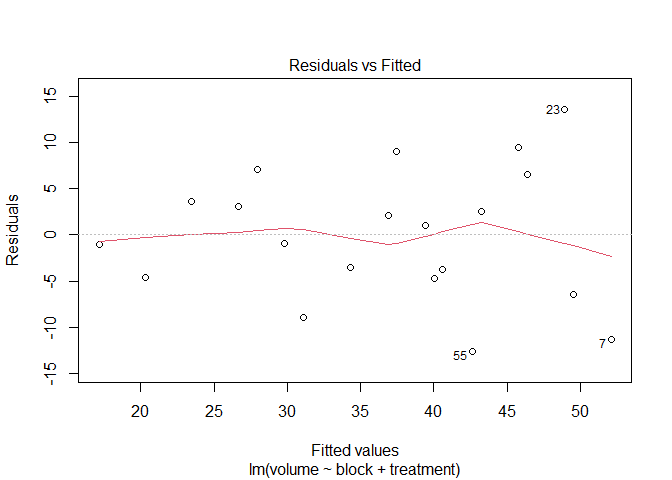

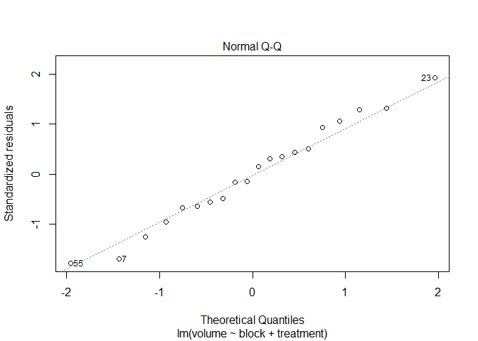

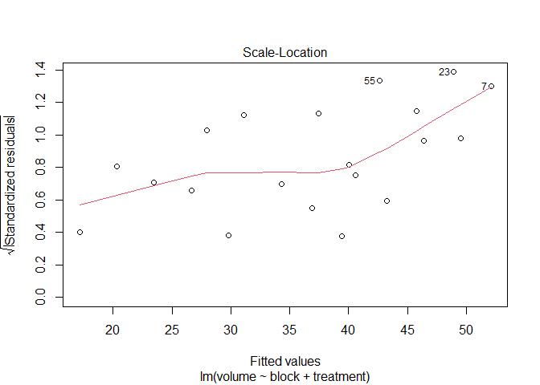

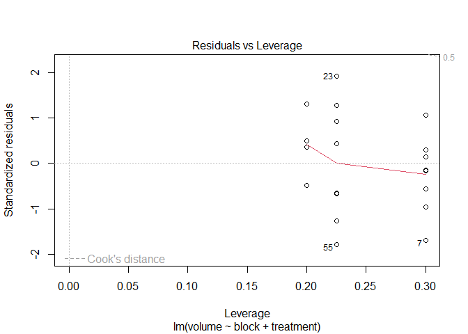

[figure not shown]

[figure not shown]

[figure not shown]

[figure not shown]

```r
plot(M.vol)
```

### Revision 5

```r
M.vol5 <- lm(volume~block+treatment,
             data = expfert[expfert$revision == 5,])
anova(M.vol5)
```

```
## Analysis of Variance Table
##
## Response: volume
##           Df  Sum Sq Mean Sq F value    Pr(>F)
## block      1   376.2   376.2  0.7221 0.4088005
## treatment  3 18234.6  6078.2 11.6683 0.0003327 ***
## Residuals 15  7813.8   520.9
## ---
## Signif. codes:  0 '***' 0.001 '**' 0.01 '*' 0.05 '.' 0.1 ' ' 1
```

The anova test shows a significant in the treatment effect on volume production.

#### Post hoc test using Tukeys HSD

```r
T.vol5 <- TukeyC(x = M.vol5, which = 'treatment')

summary(T.vol5)
```

```
## Goups of means at sig.level = 0.05
##     Means G1 G2
## F1 133.36  a
## F2 131.78  a
## F3 102.30  a
## C   58.87     b
##
## Matrix of the difference of means above diagonal and
## respective p-values of the Tukey test below diagonal values
##       F1    F2     F3      C
## F1 0.000 1.583 31.060 74.493
## F2 1.000 0.000 29.477 72.910
## F3 0.182 0.217  0.000 43.433
## C  0.001 0.001  0.039  0.000
```

**Checking for patterns in the residuals with a residual plot**

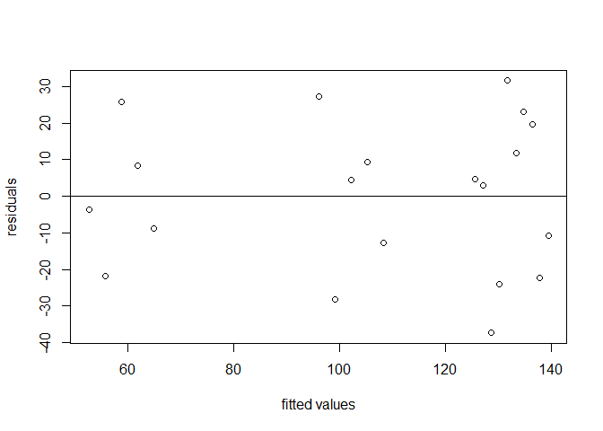

```r
plot(M.vol5$fitted.values, M.vol5$residuals,
     xlab ='fitted values',
     ylab = 'residuals')
abline(c(0,0), col = 'black')
```

### Revision 6

```r
M.vol6 <- lm(volume~block+treatment,
             data = expfert[expfert$revision == 6,])
anova(M.vol6)
```

```
## Analysis of Variance Table
##
## Response: volume
##           Df Sum Sq Mean Sq F value    Pr(>F)
## block      1   3597  3597.3  3.4533   0.08286 .
## treatment  3  57590 19196.8 18.4283 2.721e-05 ***
## Residuals 15  15626  1041.7
## ---
## Signif. codes:  0 '***' 0.001 '**' 0.01 '*' 0.05 '.' 0.1 ' ' 1
```

#### Posthoc test (Tukey HSD)

```r
T.vol6 <- TukeyC(x = M.vol6, which = 'treatment')

summary(T.vol6)
```

```
## Goups of means at sig.level = 0.05
##     Means G1 G2
## F1 241.38  a
## F2 239.30  a
## F3 202.05  a
## C  109.04     b
##
## Matrix of the difference of means above diagonal and
## respective p-values of the Tukey test below diagonal values
##       F1    F2     F3       C
## F1 0.000 2.077 39.327 132.340
## F2 1.000 0.000 37.250 130.263
## F3 0.259 0.300  0.000  93.013
## C  0.000 0.000  0.002   0.000
```

**Checking for patterns in the residuals with a residual plot**

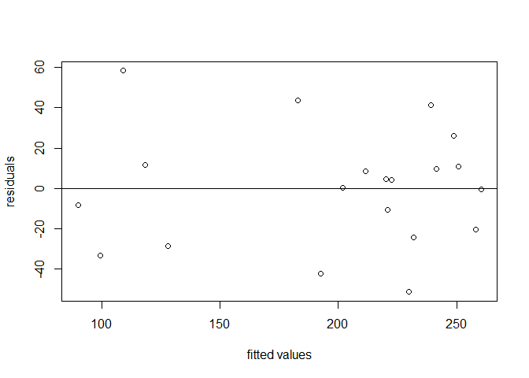

[figure not shown]

```r
plot(M.vol6$fitted.values, M.vol6$residuals,
     xlab ='fitted values',
     ylab = 'residuals')
abline(c(0,0), col = 'black')
```